# 데이터 과학자와 함께 하는 제19대 대통령 선거

페북 페이지 팬 좋아요(fan likes)시각화

## 페북 페이지 팬 좋아요

페북 페이지에 팬을 많이 확보하면 나름 여러가지 면에서 큰 도움(?)이 된다. 페북 마케팅을 활용하여 성과를 얻은 성공사례는 구글에서 흔히 검색되고 다양한 컨설팅업체도 서비스를 제공하고 있다.

엑셀을 활용한 방법도 조금 오래되었지만 자세한 안내가 나와 있다. [^1]

엑셀 대신에 R언어 생태계에서 제공되는 팩키지를 활용하여 페북 데이터를 정제한다. 가장 먼저 페이스북 개발자 웹사이트에서 제공하는 API를 숙지하고 이를 기반으로 API에서 제공하는 데이터를 긁어온다.

데이터가 JSON형태로 제공되기 때문에 JSON 파일을 R 데이터프레임으로 변환하는 방식 중 하나를 선택하여 데이터프레임으로 변환한다. 그 다음 데이터 정제 과정을 거쳐서 `ggplot` 함수로 시각화한다. [^2]

### 환경설정

페이스북 개발자 API에서 제공하는 웹페이지에서 데이터를 받아오기 위한 기본 설정을 한다.

```r
# 1. 환경설정 ---------------------------------------------------------------
library(RCurl)
library(RJSONIO)
library(tidyverse)
library(tibble)
library(stringr)
library(lubridate)
library(plyr)
library(ggthemes)
library(extrafont)
loadfonts()
```

### 팬페이지 좋아용 데이터 가져오기

`get_fb_likes` 함수를 생성하여 최대 3개월치 페북 팬좋아요 데이터를 가져온다. 이렇게 쪼개야 되는 이유는 페이스북에서 3개월치 페북 팬좋아요 데이터를 제공하기 때문이다.

국민의당 경선을 치열하게 치르고 있는 [손학규](https://www.facebook.com/koreasohn/), [안철수](https://www.facebook.com/ahncs111/) 공식 페북 페이지를 주소를 확인하고 `get_fb_likes` 함수를 통해 데이터를 쭉 긁어온다.

긁어온 데이터는 데이터 전처리 및 정제과정을 거쳐 시각화를 위한 준비를 한다.

```r
fb_keys <- "EAACEdEose0cBAAqgzxp74SSkSYdbi3FocjXRk5olE8nKY63i6WlJc0wjfYNE8SsO3l2OcgfdCDEZACkv1U60lJkbpG3UajipT4xo1bIbCJIi0LMpHSkilwAwsinVcJjqrVVCYG0L05g281ZCgP5iufmgn85KzFZCPnJ6ZBYZCyZAkRapY3PAIj"

get_fb_likes <- function(fb_pages, sdate, edate, fb_keys){
  url         <- paste0("https://graph.facebook.com/v2.8/", fb_pages, "/insights/page_fans_country/lifetime?&since=", sdate, "&until=", edate, "&access_token=", fb_keys)
  url_json    <- getURL(url)
  url_list    <- fromJSON(url_json)
  url_dat_likes  <- lapply(url_list$data[[1]]$values, function(x) {x$value})
  library(gtools)
  url_dat_df <- do.call(smartbind, url_dat_likes)
  url_dat_df[is.na(url_dat_df)] <- 0
  url_date <- lapply(url_list$data[[1]]$values, function(x) {x$end_time})
  url_date_df <- do.call(rbind, url_date)

  url_df <- cbind(url_date_df, url_dat_df)
  url_df <- url_df %>%
    mutate(url_date_df = ymd(str_sub(url_date_df, 1, 10))) %>%
    dplyr::rename(fdate=url_date_df)
  return(url_df)
}

# 2. 데이터 가져오기 ---------------------------------------------------------------
## 2.1. 손학규
sohn_16_01 <- get_fb_likes("koreasohn", "2016-01-01", "2016-03-31", fb_keys)
sohn_16_04 <- get_fb_likes("koreasohn", "2016-04-01", "2016-06-31", fb_keys)
sohn_16_07 <- get_fb_likes("koreasohn", "2016-07-01", "2016-09-31", fb_keys)
sohn_16_10 <- get_fb_likes("koreasohn", "2016-10-01", "2016-12-31", fb_keys)
sohn_17_01 <- get_fb_likes("koreasohn", "2017-01-01", "2017-02-25", fb_keys)

## 2.2. 안철수
ahn_16_01 <- get_fb_likes("ahncs111", "2016-01-01", "2016-03-31", fb_keys)
ahn_16_04 <- get_fb_likes("ahncs111", "2016-04-01", "2016-06-31", fb_keys)
ahn_16_07 <- get_fb_likes("ahncs111", "2016-07-01", "2016-09-31", fb_keys)
ahn_16_10 <- get_fb_likes("ahncs111", "2016-10-01", "2016-12-31", fb_keys)
ahn_17_01 <- get_fb_likes("ahncs111", "2017-01-01", "2017-02-25", fb_keys)

# 3. 데이터 정제하기 ---------------------------------------------------------------
# 3.1. 손학규-----------------------------------------------------------------------
sohn_fan_likes <- sohn_16_01 %>%
  bind_rows(sohn_16_04) %>%
  bind_rows(sohn_16_07) %>%
  bind_rows(sohn_16_10) %>%
  bind_rows(sohn_17_01)
sohn_fan_likes[is.na(sohn_fan_likes)] <- 0

sohn_fan_likes_df <- sohn_fan_likes %>% select(2:length(sohn_fan_likes)) %>%
  mutate(fan_likes = rowSums(.)) %>% dplyr::select(fan_likes)

sohn_fan_likes <- bind_cols(sohn_fan_likes, sohn_fan_likes_df)

## 3.2. 안철수-----------------------------------------------------------------------
ahn_fan_likes <- ahn_16_01 %>%
  bind_rows(ahn_16_04) %>%
  bind_rows(ahn_16_07) %>%
  bind_rows(ahn_16_10) %>%
  bind_rows(ahn_17_01)
ahn_fan_likes[is.na(ahn_fan_likes)] <- 0

ahn_fan_likes_df <- ahn_fan_likes %>% select(2:length(ahn_fan_likes)) %>%
  mutate(fan_likes = rowSums(.)) %>% dplyr::select(fan_likes)

ahn_fan_likes <- bind_cols(ahn_fan_likes, ahn_fan_likes_df)
```

### 손학규, 안철수 팬좋아요 시각화

[손학규](https://www.facebook.com/koreasohn/), 안철수 공식 페북 페이지에 팬 좋아요 갯수를 `ggplot`으로 시각화한다.

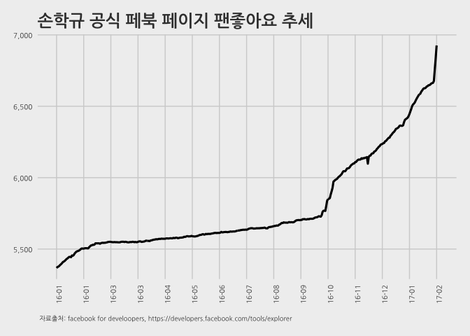

```r
# 4. 추세 시각화 ---------------------------------------------------------------
## 4.1. 손학규-----------------------------------------------------------------------
dlist <- unique(sohn_fan_likes$fdate)

ggplot(sohn_fan_likes, aes(x=fdate, y=fan_likes)) +
  geom_line(size=1.1) +
  # geom_vline(xintercept=as.numeric(ymd("2008-01-01")), linetype=2) +
  scale_x_date(breaks=seq(dlist[1], tail(dlist, n=1) + days(1), "30 day"),
               date_labels= "%y-%m", limits=c(dlist[1],tail(dlist, n=1) + days(1))) +
  scale_y_continuous(label=scales::comma) +
  theme_fivethirtyeight(base_family="NanumGothic") +
  theme(legend.position="none",
        plot.caption=element_text(hjust=0,size=7),
        plot.subtitle=element_text(face="italic"),
        axis.text=element_text(size=7.5),
        axis.text.x = element_text(angle = 90, hjust = 1))+
  labs(x="",y="",title="손학규 공식 페북 페이지 팬좋아요 추세",
       caption="\n 자료출처: facebook for develoopers, https://developers.facebook.com/tools/explorer")
```

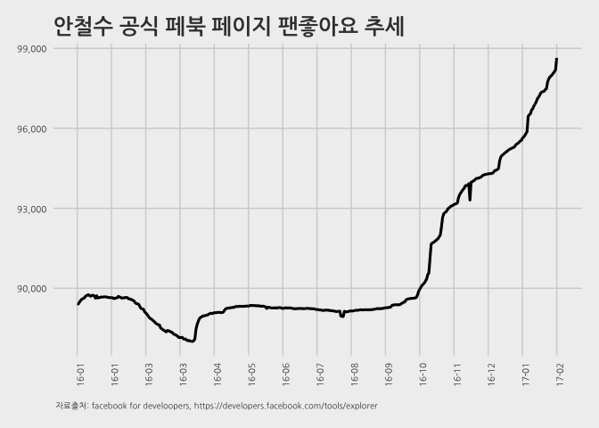

```r
## 4.2. 안철수-----------------------------------------------------------------------
dlist <- unique(ahn_fan_likes$fdate)

ggplot(ahn_fan_likes, aes(x=fdate, y=fan_likes)) +
  geom_line(size=1.1) +
  # geom_vline(xintercept=as.numeric(ymd("2008-01-01")), linetype=2) +
  scale_x_date(breaks=seq(dlist[1], tail(dlist, n=1) + days(1), "30 day"),
               date_labels= "%y-%m", limits=c(dlist[1],tail(dlist, n=1) + days(1))) +
  scale_y_continuous(label=scales::comma) +
  theme_fivethirtyeight(base_family="NanumGothic") +
  theme(legend.position="none",
        plot.caption=element_text(hjust=0,size=7),
        plot.subtitle=element_text(face="italic"),
        axis.text=element_text(size=7.5),
        axis.text.x = element_text(angle = 90, hjust = 1))+
  labs(x="",y="",title="안철수 공식 페북 페이지 팬좋아요 추세",
       caption="\n 자료출처: facebook for develoopers, https://developers.facebook.com/tools/explorer")
```

[^1]: [How to extract Facebook page likes history by countries to Excel](https://nocodewebscraping.com/how-to-check-facebook-page-likes-history-by-countries/)
[^2]: [Parsing Facebook JSON results in R](http://stackoverflow.com/questions/15758077/parsing-facebook-json-results-in-r)